# Code For Spotify Dataset Analysis

Here is a revised version for the code submission. I mainly worked on the things you have already done, added a few minor tweaks. On each step I will show you where and what I have tweaked so we can discuss what to keep and what to change. Our three questions are...

- Does **collaboration** between artists **affect the popularity** of a song?
- How do features like **energy, danceability, and acousticness** vary between collaborative and solo tracks?
- What is the correlation between different **musical features** within albums, and how does **popularity** fit into this?

First, here are the first 5 rows of the Spotify dataset to see what we are working with...

```python
import pandas as pd

# Load the dataset
df_dataset = pd.read_csv("dataset.csv")

#Display the first few rows
df.head()
```

[output not shown]

5 rows × 23 columns

### Cleaning - (Updated)

After loading the dataset, we see that there is an a useless column called "unnamed: 0", which we can just remove since it mainly acts as an indexing column. I also standardized the artist column in a list so it would be easier to sort through and check for collaborations and solos. Removed missing values and made sure that the data types are in numeric format.

```python
df_dataset = pd.read_csv("dataset.csv")

# Drop unnecessary columns
if 'Unnamed: 0' in df_dataset.columns:
    df_dataset = df_dataset.drop(columns=['Unnamed: 0'])

# Check for missing values
missing_values = df_dataset.isnull().sum()

# Ensure data types are appropriate for analysis
df_dataset['popularity'] = pd.to_numeric(df_dataset['popularity'], errors='coerce')
df_dataset['duration_ms'] = pd.to_numeric(df_dataset['duration_ms'], errors='coerce')

# Handle missing or malformed data
df_dataset = df_dataset.dropna()

# Clean and standardise the artists column
df_dataset['artists'] = df_dataset['artists'].str.split(';').apply(lambda x: [artist.strip() for artist in x])

df_dataset.head()
```

|  | track_id | artists | album_name | track_name | popularity | duration_ms | explicit | danceability | energy | key | loudness | mode | speechiness | acousticness | instrumentalness | liveness | valence | tempo | time_signature | track_genre |
| --- | --- | --- | --- | --- | --- | --- | --- | --- | --- | --- | --- | --- | --- | --- | --- | --- | --- | --- | --- | --- |
| 0 | 5SuOikwiRyPMVoIQDJUgSV | [Gen Hoshino] | Comedy | Comedy | 73 | 230666 | False | 0.676 | 0.4610 | 1 | -6.746 | 0 | 0.1430 | 0.0322 | 0.000001 | 0.3580 | 0.715 | 87.917 | 4 | acoustic |
| 1 | 4qPNDBW1i3p13qLCt0Ki3A | [Ben Woodward] | Ghost (Acoustic) | Ghost - Acoustic | 55 | 149610 | False | 0.420 | 0.1660 | 1 | -17.235 | 1 | 0.0763 | 0.9240 | 0.000006 | 0.1010 | 0.267 | 77.489 | 4 | acoustic |
| 2 | 1iJBSr7s7jYXzM8EGcbK5b | [Ingrid Michaelson, ZAYN] | To Begin Again | To Begin Again | 57 | 210826 | False | 0.438 | 0.3590 | 0 | -9.734 | 1 | 0.0557 | 0.2100 | 0.000000 | 0.1170 | 0.120 | 76.332 | 4 | acoustic |
| 3 | 6lfxq3CG4xtTiEg7opyCyx | [Kina Grannis] | Crazy Rich Asians (Original Motion Picture Sou... | Can't Help Falling In Love | 71 | 201933 | False | 0.266 | 0.0596 | 0 | -18.515 | 1 | 0.0363 | 0.9050 | 0.000071 | 0.1320 | 0.143 | 181.740 | 3 | acoustic |
| 4 | 5vjLSffimiIP26QG5WcN2K | [Chord Overstreet] | Hold On | Hold On | 82 | 198853 | False | 0.618 | 0.4430 | 2 | -9.681 | 1 | 0.0526 | 0.4690 | 0.000000 | 0.0829 | 0.167 | 119.949 | 4 | acoustic |

#### Cleaning (Old)

Here is what we had before my changes

```python
# Handling missing values
df = df.dropna()

# Create a new column to indicate collaboration
df['is_collaboration'] = df['artists'].apply(lambda x: len(x.split(';')) > 1)

# Create a new column for highly popular songs
df['is_highly_popular'] = df['popularity'] > 70

# Check the cleaned data (uncomment to run and show head if you want to compare the old df and the updated one)
# df.head()
```

### Exploratory Data Analysis - (Updated)

#### General Overview

First, we will start with a general overview to see what the data we are working with looks like. If there are any correlations betweene existing attributes and how these variables interact. This is mainly to gather more insight into the data that we are working with.

```python
# Summary statistics for numerical columns
summary_statistics = df_dataset.describe()

print(summary_statistics)
```

```
          popularity   duration_ms   danceability         energy  \
count  113999.000000  1.139990e+05  113999.000000  113999.000000
mean       33.238827  2.280312e+05       0.566801       0.641383
std        22.304959  1.072961e+05       0.173543       0.251530
min         0.000000  8.586000e+03       0.000000       0.000000
25%        17.000000  1.740660e+05       0.456000       0.472000
50%        35.000000  2.129060e+05       0.580000       0.685000
75%        50.000000  2.615060e+05       0.695000       0.854000
max       100.000000  5.237295e+06       0.985000       1.000000

                 key       loudness           mode    speechiness  \
count  113999.000000  113999.000000  113999.000000  113999.000000
mean        5.309126      -8.258950       0.637558       0.084652
std         3.559999       5.029357       0.480708       0.105733
min         0.000000     -49.531000       0.000000       0.000000
25%         2.000000     -10.013000       0.000000       0.035900
50%         5.000000      -7.004000       1.000000       0.048900
75%         8.000000      -5.003000       1.000000       0.084500
max        11.000000       4.532000       1.000000       0.965000

        acousticness  instrumentalness       liveness        valence  \
count  113999.000000     113999.000000  113999.000000  113999.000000
mean        0.314907          0.156051       0.213554       0.474066
std         0.332522          0.309556       0.190378       0.259261
min         0.000000          0.000000       0.000000       0.000000
25%         0.016900          0.000000       0.098000       0.260000
50%         0.169000          0.000042       0.132000       0.464000
75%         0.597500          0.049000       0.273000       0.683000
max         0.996000          1.000000       1.000000       0.995000

               tempo  time_signature
count  113999.000000   113999.000000
mean      122.147695        3.904034
std        29.978290        0.432623
min         0.000000        0.000000
25%        99.218500        4.000000
50%       122.017000        4.000000
75%       140.071000        4.000000
max       243.372000        5.000000
```

#### General Overview - Graphs & Histograms (EDA)

Now lets print some graphs and histograms.

**Distribution of Track Popularity**  
This one is the one we had before, it works great

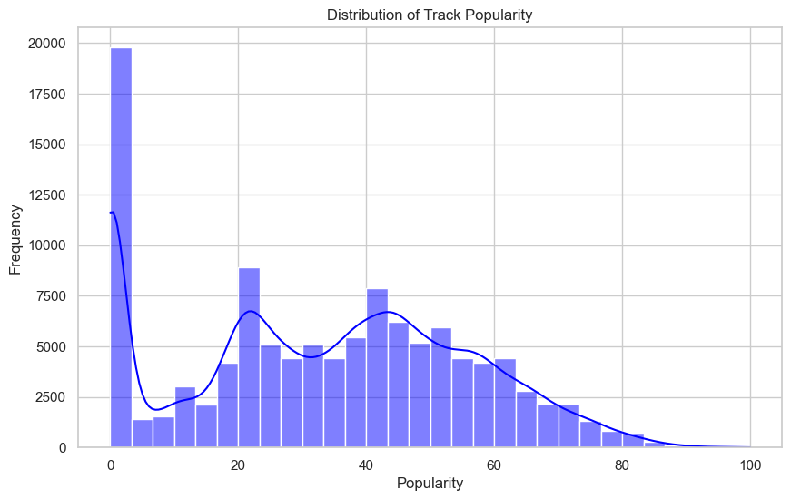

```python
import seaborn as sns
import matplotlib.pyplot as plt
sns.set(style="whitegrid")

# Visualize the distribution of popularity
plt.figure(figsize=(10, 6))
sns.histplot(df['popularity'], kde=True, bins=30, color='blue')
plt.title('Distribution of Track Popularity')
plt.xlabel('Popularity')
plt.ylabel('Frequency')
plt.show()
```

**Correlation Analysis**  
This is just a more detailed correlation matrix (relative to the one before) to account for all the numerical variables...

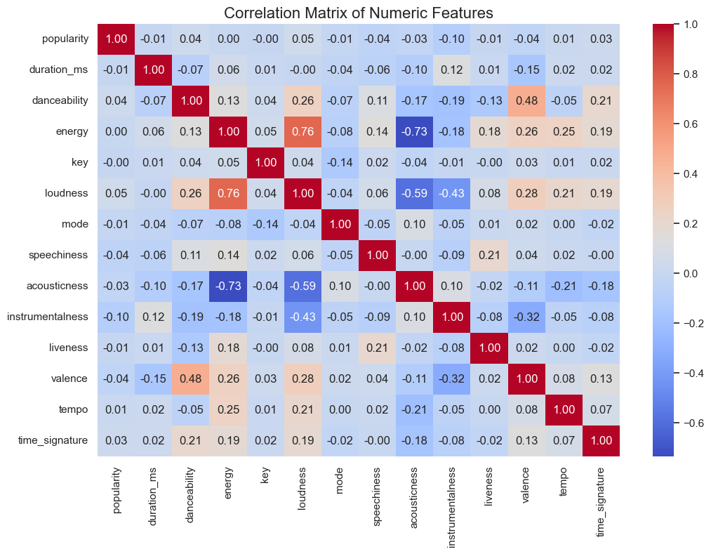

```python
import seaborn as sns
import matplotlib.pyplot as plt

# Account for all numeric values to plot on heatmap
numeric_df = df_dataset.select_dtypes(include=['float64', 'int64'])

correlation_matrix = numeric_df.corr()

# Plot the correlation heatmap between all variables
plt.figure(figsize=(12, 8))
sns.heatmap(correlation_matrix, annot=True, cmap='coolwarm', fmt='.2f', cbar=True)
plt.title('Correlation Matrix of Numeric Features', fontsize=16)
plt.show()
```

**Collab Vs. Solo - Avg. Popularity**  
This is a simple comparison between collabs and solo songs to answer whether collaboration affects the popularity of a song.

```python
# Funciton to indentify if the song is a collab or not
def is_collaboration(artists):
    return len(artists) > 1

# Create new column to assign to each song to see if song is collab or not
df_dataset['is_collaboration'] = df_dataset['artists'].apply(is_collaboration)

# Calculate avg popularity relative to boolean is_collab
collaboration_stats = df_dataset.groupby('is_collaboration')['popularity'].mean().reset_index()
collaboration_stats.columns = ['Is Collaboration', 'Average Popularity']

collaboration_stats
```

|  | Is Collaboration | Average Popularity |
| --- | --- | --- |
| 0 | False | 33.069587 |
| 1 | True | 33.711089 |

## Continue from here... (not yet revised)

#### Exploratory Data Analysis (Old)

Here is what we had before...

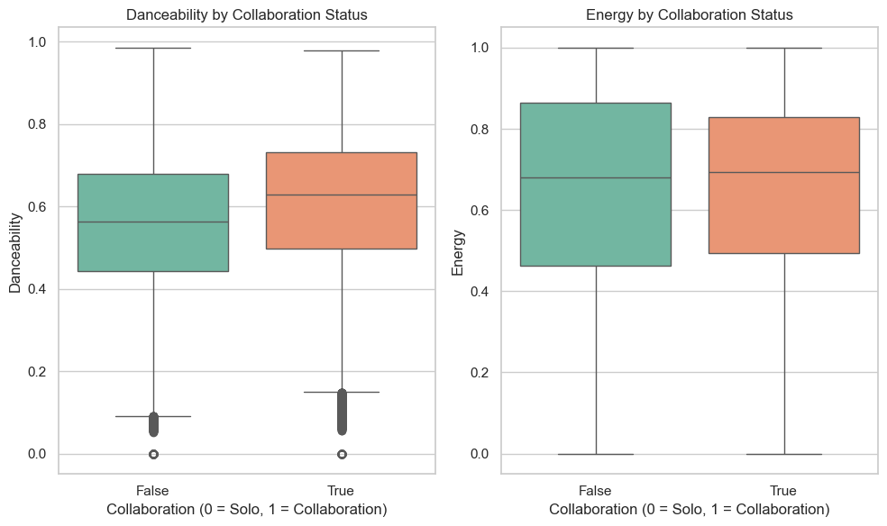

```python
import matplotlib.pyplot as plt
import seaborn as sns

sns.set(style="whitegrid")

# Visualize the distribution of danceability and energy across collaboration vs solo tracks
plt.figure(figsize=(10, 6))

# Danceability
plt.subplot(1, 2, 1)
sns.boxplot(x='is_collaboration', y='danceability', data=df, palette='Set2')
plt.title('Danceability by Collaboration Status')
plt.xlabel('Collaboration (0 = Solo, 1 = Collaboration)')
plt.ylabel('Danceability')

# Energy
plt.subplot(1, 2, 2)
sns.boxplot(x='is_collaboration', y='energy', data=df, palette='Set2')
plt.title('Energy by Collaboration Status')
plt.xlabel('Collaboration (0 = Solo, 1 = Collaboration)')
plt.ylabel('Energy')

plt.tight_layout()
plt.show()
```

# Investigate Popularity Influence Within Albums

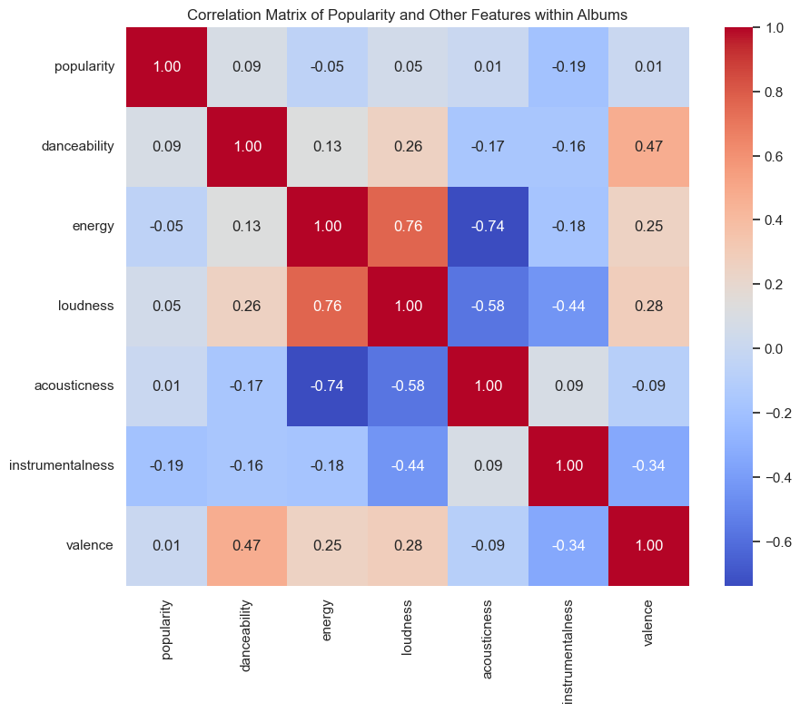

```python
# Group by album_name
album_group = df.groupby('album_name').agg({
    'popularity': 'mean',
    'danceability': 'mean',
    'energy': 'mean',
    'loudness': 'mean',
    'acousticness': 'mean',
    'instrumentalness': 'mean',
    'valence': 'mean'
}).reset_index()

# Select only numerical features for correlation calculation
numerical_features = ['popularity', 'danceability', 'energy', 'loudness', 'acousticness', 'instrumentalness', 'valence']
corr_matrix = album_group[numerical_features].corr()

# Plot the correlation heatmap
plt.figure(figsize=(10, 8))
sns.heatmap(corr_matrix, annot=True, cmap='coolwarm', fmt='.2f', cbar=True)
plt.title('Correlation Matrix of Popularity and Other Features within Albums')
plt.show()
```

```python
# Print the correlation matrix for popularity and other features within albums
print("Correlation Matrix of Popularity and Other Features within Albums:")
print(corr_matrix)
```

```
Correlation Matrix of Popularity and Other Features within Albums:
                  popularity  danceability    energy  loudness  acousticness  \
popularity          1.000000      0.089224 -0.053594  0.049201      0.005569
danceability        0.089224      1.000000  0.125278  0.256904     -0.167071
energy             -0.053594      0.125278  1.000000  0.763619     -0.739488
loudness            0.049201      0.256904  0.763619  1.000000     -0.576175
acousticness        0.005569     -0.167071 -0.739488 -0.576175      1.000000
instrumentalness   -0.189612     -0.164412 -0.181762 -0.437635      0.088845
valence             0.006580      0.472460  0.247226  0.280343     -0.090952

                  instrumentalness   valence
popularity               -0.189612  0.006580
danceability             -0.164412  0.472460
energy                   -0.181762  0.247226
loudness                 -0.437635  0.280343
acousticness              0.088845 -0.090952
instrumentalness          1.000000 -0.340629
valence                  -0.340629  1.000000
```

# Statistical Test: Comparing Features of Collaboration vs Solo Tracks

```python
from scipy import stats

# Separate the solo and collaboration tracks
solo_tracks = df[df['is_collaboration'] == False]
collab_tracks = df[df['is_collaboration'] == True]

# Perform t-test for danceability
danceability_ttest = stats.ttest_ind(solo_tracks['danceability'], collab_tracks['danceability'])
print(f"T-test for danceability: {danceability_ttest}")

# Perform t-test for energy
energy_ttest = stats.ttest_ind(solo_tracks['energy'], collab_tracks['energy'])
print(f"T-test for energy: {energy_ttest}")

# Perform t-test for acousticness
acousticness_ttest = stats.ttest_ind(solo_tracks['acousticness'], collab_tracks['acousticness'])
print(f"T-test for acousticness: {acousticness_ttest}")

# Perform t-test for instrumentalness
instrumentalness_ttest = stats.ttest_ind(solo_tracks['instrumentalness'], collab_tracks['instrumentalness'])
print(f"T-test for instrumentalness: {instrumentalness_ttest}")
```

```
T-test for danceability: TtestResult(statistic=-43.53832958892287, pvalue=0.0, df=113997.0)
T-test for energy: TtestResult(statistic=1.6401976525208093, pvalue=0.10096683630366105, df=113997.0)
T-test for acousticness: TtestResult(statistic=6.853293495508051, pvalue=7.2533491025992336e-12, df=113997.0)
T-test for instrumentalness: TtestResult(statistic=10.52634966189129, pvalue=6.713244868562422e-26, df=113997.0)
```

# Regression Model to Predict Popularity

```python
from sklearn.model_selection import train_test_split
from sklearn.metrics import mean_squared_error, r2_score
from sklearn.tree import DecisionTreeRegressor
from sklearn.ensemble import RandomForestRegressor

# Select features and target
X = df[['danceability', 'energy', 'loudness', 'acousticness', 'valence']]
y = df['popularity']

# Split the dataset into training and test sets
X_train, X_test, y_train, y_test = train_test_split(X, y, test_size=0.2, random_state=42)

# Decision Tree Regressor
decision_tree = DecisionTreeRegressor(random_state=42)
decision_tree.fit(X_train, y_train)
y_pred_tree = decision_tree.predict(X_test)

# Random Forest Regressor
random_forest = RandomForestRegressor(n_estimators=100, random_state=42)
random_forest.fit(X_train, y_train)
y_pred_forest = random_forest.predict(X_test)

# Evaluate Decision Tree
print(f"Decision Tree Mean Squared Error: {mean_squared_error(y_test, y_pred_tree)}")
print(f"Decision Tree R-squared: {r2_score(y_test, y_pred_tree)}")

# Evaluate Random Forest
print(f"Random Forest Mean Squared Error: {mean_squared_error(y_test, y_pred_forest)}")
print(f"Random Forest R-squared: {r2_score(y_test, y_pred_forest)}")
```

```
Decision Tree Mean Squared Error: 446.6630023758144
Decision Tree R-squared: 0.09963217072140085
Random Forest Mean Squared Error: 246.50606993843147
Random Forest R-squared: 0.5031015913251697
```

# Visualizing the Impact of Collaboration on Other Features

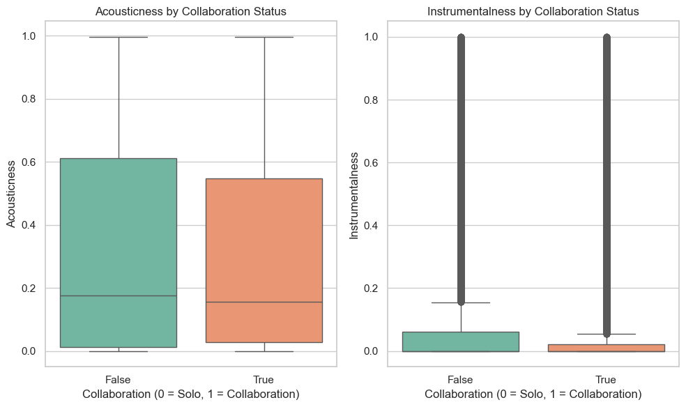

```python
# Visualize the impact of collaboration on acousticness and instrumentalness
plt.figure(figsize=(10, 6))

# Acousticness
plt.subplot(1, 2, 1)
sns.boxplot(x='is_collaboration', y='acousticness', data=df, palette='Set2')
plt.title('Acousticness by Collaboration Status')
plt.xlabel('Collaboration (0 = Solo, 1 = Collaboration)')
plt.ylabel('Acousticness')

# Instrumentalness
plt.subplot(1, 2, 2)
sns.boxplot(x='is_collaboration', y='instrumentalness', data=df, palette='Set2')
plt.title('Instrumentalness by Collaboration Status')
plt.xlabel('Collaboration (0 = Solo, 1 = Collaboration)')
plt.ylabel('Instrumentalness')

plt.tight_layout()
plt.show()
```

```python
# Print summary statistics for Acousticness and Instrumentalness based on collaboration status
print("Summary Statistics for Acousticness by Collaboration Status:")
print(df.groupby('is_collaboration')['acousticness'].describe())

print("\nSummary Statistics for Instrumentalness by Collaboration Status:")
print(df.groupby('is_collaboration')['instrumentalness'].describe())
```

```
Summary Statistics for Acousticness by Collaboration Status:
                    count      mean       std  min     25%    50%    75%  \
is_collaboration
False             83924.0  0.318946  0.334413  0.0  0.0129  0.175  0.612
True              30075.0  0.303634  0.326930  0.0  0.0278  0.157  0.548

                    max
is_collaboration
False             0.996
True              0.996

Summary Statistics for Instrumentalness by Collaboration Status:
                    count      mean       std  min  25%       50%     75%  max
is_collaboration
False             83924.0  0.161825  0.314479  0.0  0.0  0.000055  0.0621  1.0
True              30075.0  0.139937  0.294791  0.0  0.0  0.000021  0.0220  1.0
```